# `mice`: multivariate imputation by chained equations

### 4) Imputation

Now it’s time to impute! Here, we have specified that we want `m=20` imputations (20 versions of the dataset) and `maxit=20` iterations (20 iterations for convergence). We have also manually specified the imputation method and predictor matrix, and have turned print off (otherwise it gets very busy, but this is entirely up to you). For the number of imputations, this is really a trade off between power (the more the better) and computational resource.

```r
imp <- mice(df,m=20,maxit=20,meth=meth,pred=pred,seed=500,print=FALSE) #impute
summary(imp)
```

```
## Class: mids
## Number of multiple imputations:  20
## Imputation methods:
## Sepal.Length  Sepal.Width Petal.Length  Petal.Width      Species
##           ""           ""        "pmm"           ""    "polyreg"
## PredictorMatrix:
##              Sepal.Length Sepal.Width Petal.Length Petal.Width Species
## Sepal.Length            0           1            1           1       1
## Sepal.Width             0           0            1           1       1
## Petal.Length            0           1            0           1       1
## Petal.Width             0           1            1           0       1
## Species                 0           1            1           1       0
```

**NB These mids objects that are created during mice imputation can get very large!**

```r
object.size(df)
```

```
## 7256 bytes
```

```r
object.size(imp)
```

```
## 112464 bytes
```

#### Checking imputation:

We can also check whether the imputation has converged by calling `plot` on our imputation object; here, we want to see that the iterations intermingle and that there are no distinct patterns. Another useful check is ``stripplot`, where we can view the imputed values at each imputation; we can check here whether the imputed data are plausible.

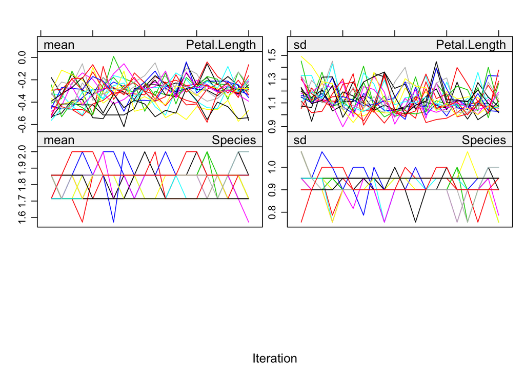

```r
plot(imp)
```

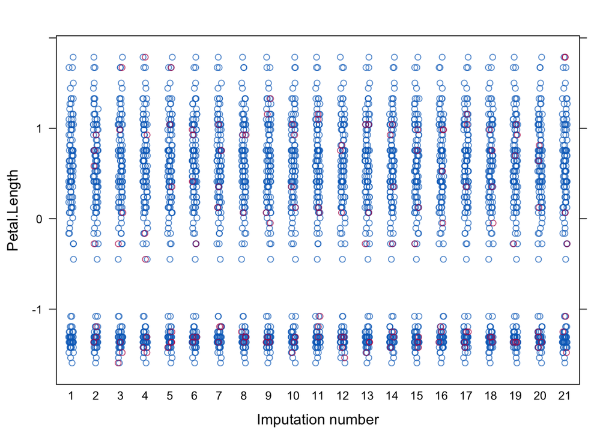

```r
stripplot(imp, Petal.Length~.imp)
```

#### And here you can see the summary for each of the imputations:

```r
dim(df)
```

```
## [1] 150   5
```

```r
summary(complete(imp, 0)) #original data
```

```
##   Sepal.Length       Sepal.Width       Petal.Length      Petal.Width
##  Min.   :-1.86378   Min.   :-2.4258   Min.   :-1.5958   Min.   :-1.4422
##  1st Qu.:-0.89767   1st Qu.:-0.5904   1st Qu.:-1.2805   1st Qu.:-1.1799
##  Median :-0.05233   Median :-0.1315   Median : 0.3537   Median : 0.1321
##  Mean   : 0.00000   Mean   : 0.0000   Mean   : 0.0000   Mean   : 0.0000
##  3rd Qu.: 0.67225   3rd Qu.: 0.5567   3rd Qu.: 0.7550   3rd Qu.: 0.7880
##  Max.   : 2.48370   Max.   : 3.0805   Max.   : 1.7871   Max.   : 1.7064
##                                       NA's   :7
##        Species
##  setosa    :46
##  versicolor:49
##  virginica :48
##  NA's      : 7
##
##
##
```

```r
summary(complete(imp, 20)) #imputation number 20 - selected this at random for demonstration
```

```
##   Sepal.Length       Sepal.Width       Petal.Length        Petal.Width
##  Min.   :-1.86378   Min.   :-2.4258   Min.   :-1.595841   Min.   :-1.4422
##  1st Qu.:-0.89767   1st Qu.:-0.5904   1st Qu.:-1.251813   1st Qu.:-1.1799
##  Median :-0.05233   Median :-0.1315   Median : 0.324982   Median : 0.1321
##  Mean   : 0.00000   Mean   : 0.0000   Mean   :-0.002991   Mean   : 0.0000
##  3rd Qu.: 0.67225   3rd Qu.: 0.5567   3rd Qu.: 0.755017   3rd Qu.: 0.7880
##  Max.   : 2.48370   Max.   : 3.0805   Max.   : 1.787102   Max.   : 1.7064
##        Species
##  setosa    :49
##  versicolor:51
##  virginica :50
##
##
##
```

```r
summary(complete(imp)) #all imputed datasets
```

```
##   Sepal.Length       Sepal.Width       Petal.Length       Petal.Width
##  Min.   :-1.86378   Min.   :-2.4258   Min.   :-1.59584   Min.   :-1.4422
##  1st Qu.:-0.89767   1st Qu.:-0.5904   1st Qu.:-1.29482   1st Qu.:-1.1799
##  Median :-0.05233   Median :-0.1315   Median : 0.35365   Median : 0.1321
##  Mean   : 0.00000   Mean   : 0.0000   Mean   :-0.01255   Mean   : 0.0000
##  3rd Qu.: 0.67225   3rd Qu.: 0.5567   3rd Qu.: 0.75502   3rd Qu.: 0.7880
##  Max.   : 2.48370   Max.   : 3.0805   Max.   : 1.78710   Max.   : 1.7064
##        Species
##  setosa    :49
##  versicolor:51
##  virginica :50
##
##
##
```

### 5) Analysis

Finally, you can perform some analyses and pool the results! `with` is from the `mice` package and can be used for a range of statistical analyses - what it is essentially doing here is applying the analysis to each individual dataset. You can see each individual set of results by calling `model$analyses`. Then, you can pool the results, which then appear as they would with a non-imputed dataset.

```r
model <- with(imp, lm(Sepal.Length ~ Petal.Width + Sepal.Width + Species + Petal.Length)) #analysis
res <- summary(pool(model), conf.int = TRUE) #pool results
res
```

```
##                term   estimate  std.error statistic       df      p.value
## 1       (Intercept)  0.6870069 0.30153907  2.278335 63.51246 2.607989e-02
## 2       Petal.Width -0.1752962 0.16229590 -1.080102 88.61048 2.830276e-01
## 3       Sepal.Width  0.2794925 0.05557018  5.029540 99.86203 2.171117e-06
## 4 Speciesversicolor -0.8202815 0.37793467 -2.170432 62.63951 3.377304e-02
## 5  Speciesvirginica -1.1596291 0.51594875 -2.247566 64.46885 2.803237e-02
## 6      Petal.Length  1.6162998 0.17919985  9.019538 81.56496 6.883383e-14
##         2.5 %      97.5 %
## 1  0.08452431  1.28948953
## 2 -0.49779424  0.14720183
## 3  0.16924093  0.38974398
## 4 -1.57560875 -0.06495427
## 5 -2.19021083 -0.12904727
## 6  1.25978578  1.97281391
```

### Potential issues

- Large amounts of missing data
- Highly correlated predictors

### Resources

- [Flexible Imputation of Missing Data - Stef van Buuren](https://stefvanbuuren.name/fimd/)
- [MICE is Nice, but why should you care? - Medium](https://medium.com/@ofirdi/mice-is-nice-but-why-should-you-care-e66698f245a3)
- [Multiple imputation by chained equations: what is it and how does it work? - Azur et al., 2011](https://www.ncbi.nlm.nih.gov/pmc/articles/PMC3074241/)
- [Imputing Missing Data with R; MICE package - Datascienceplus](https://datascienceplus.com/imputing-missing-data-with-r-mice-package/)
- [mice: Algorithmic convergence and inference pooling - Gerko Vink & Stef van Buuren](https://www.gerkovink.com/miceVignettes/Convergence_pooling/Convergence_and_pooling.html)
- [Applied Missing Data Analysis with SPSS & RStudio, Heymans & Eekhourt, 2019](https://bookdown.org/mwheymans/bookmi/multiple-imputation.html#multiple-imputation-in-r)